# Introduction: Graphics and Principles of Data Visualisation

Seminar: Data Visualisation: Principles, Practices and Applications

Julia Schulte-Cloos

University of Marburg

November 19, 2024

✉️ julia.schulte-cloos@uni-marburg.de

# Welcome

## What makes a good graph?

- 💬 Mindmap 💬
- 📊 Results 📊

#### 01_Graphics

What makes for a good data visualisation?

Please note up to five key characteristics that make for a good data visualisation.

[figure not shown]

[interactive chart not shown]

# Overview of the workshop

## Overview

1️⃣ Why Data Visualization?

2️⃣️ Foundations of the Grammar of Graphics

3️⃣️ Hands on - Fundamentals of ggplot

4️⃣ Advanced Visualizations

5️⃣ Hands on - Advanced ggplot applications

## Learning Outcomes

What can you expect to get out of this workshop?

**At the end of the workshop, you will be able to…**:

- Understand the principles of data visualization and best practices
- Comprehend the grammar of graphics for creating structured visualizations
- Apply the principles of ggplot to design effective data visualizations
- Readily create both simple and advanced visualizations
- Develop visualizations that incorporate maps and geospatial data
- Enhance your graphs and visualizations with advanced styling and textual elements
- Design interactive visualizations to engage your audience

## Why visualizations?

> any effort to help people understand the significance of data by placing it in a visual context
- to explore your own data
  - exploratory analysis
  - outlier detection
- to communicate and report
  - …clearly (using good design principles)
  - …precisely and accurately (a plot is worth 1000 words)
  - …effectively and efficiently
- purpose: convey information and make a point (Wilke 2019)
- …data rarely speaks for itself
- to represent results of statistical analyses
- to formulate hypotheses and understand summarize theory

## Types of variables in data visualization scenarios

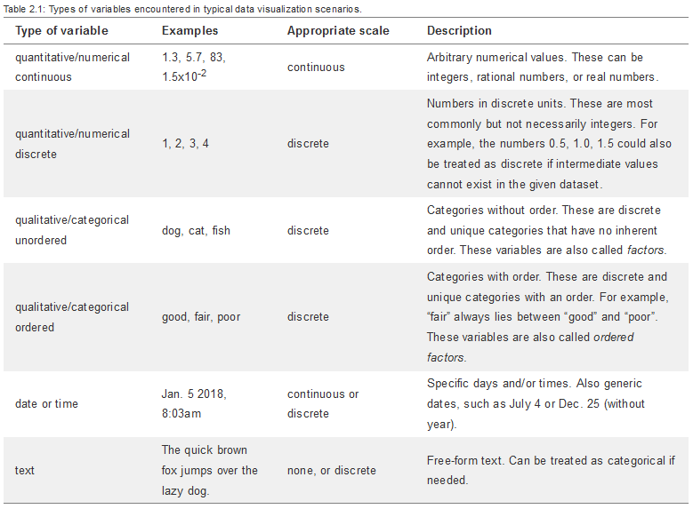

Wilke 2019 (Fundamentals of Data Visualisation)

# Application 1

**Consider some seminal studies relevant to your field and some recent top-tier publications in your field. How have practices of data visualisation changed?**

🤓 Do you know of any interactive data visualisations in your field? How would you find out about such interactive visualisations?

➡️ Bonus: are there any [“isotype visualisations”](https://clauswilke.com/dataviz/telling-a-story.html) in your field?

## A few great people working on ggplot2 and data visualisation

- [Thomas Lin Pedersen](https://github.com/thomasp85)
- [Cedric Scherer](https://github.com/Z3tt/)
- [Rohan Alexander](https://tellingstorieswithdata.com/)
- [Allison Horst](https://github.com/allisonhorst)
- [Andrew Heiss](https://datavizf23.classes.andrewheiss.com/)
- [Winston Chang](https://r-graphics.org/)

➡️ workshop material heavily draws on their excellent workshops and practical materials

# Questions? 🙋 🙋‍♂️

# Thanks for your attention.

## References

[figure not shown]

Wilke, Claus O. 2019. *Fundamentals of Data Visualization: A Primer on Making Informative and Compelling Figures*. O’Reilly Media.